# Compositional analysis of The Cancer Genome Atlas

This vignette from the R package JMDplots version 1.2.5 shows compositional metrics and phylostrata for proteins associated with transcripts that are differentially expressed in cancer compared to normal tissue (data from [The Cancer Genome Atlas](https://www.genome.gov/Funded-Programs-Projects/Cancer-Genome-Atlas) and [Genotype-Tissue Expression Project](https://www.genome.gov/Funded-Programs-Projects/Genotype-Tissue-Expression-Project) via [GEPIA2](http://gepia2.cancer-pku.cn/)). The analysis is described in more detail in a paper ([Dick, 2020](https://doi.org/10.1002/cso2.1007)). Abbreviations:

- *Z*<sub>C</sub> – average oxidation state of carbon.
- *n*<sub>H<sub>2</sub>O</sub> – stoichiometric hydration state per residue ([Dick et al., 2020](https://doi.org/10.5194/bg-17-6145-2020)) computed using the **QEC** basis species (glutamine, glutamic acid, cysteine, H<sub>2</sub>O, O<sub>2</sub>).
- PS – phylostratum; *n*<sub>AA</sub> – protein length; MW – molecular weight per residue.

Gene ages, expressed as phylostratum numbers, are taken from [Trigos et al., 2017](https://doi.org/10.1073/pnas.1617743114) (TPPG17) or [Liebeskind et al, 2016](https://doi.org/10.1093/gbe/evw113) (LMM16).

```r
datasets <- pdat_TCGA()
```

Differences are calculated as (median value for up-regulated proteins) - (median value for down-regulated proteins), except for phylostrata, where mean values are used. Dashed lines enclose the 50% credible region for highest probability density.

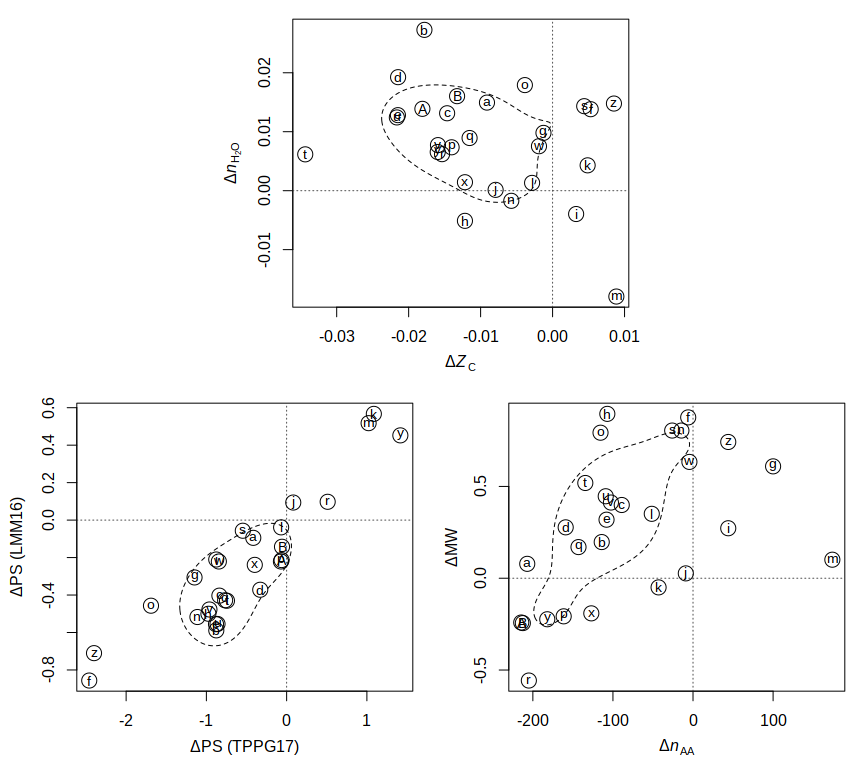

In the table, values of Δ*Z*<sub>C</sub> and Δ*n*<sub>H<sub>2</sub>O</sub> are multiplied by 1000, values of ΔPS and ΔMW are multiplied by 100, and negative values are shown in bold. Abbreviations:

- *n*<sub>down</sub> – number of down-regulated proteins; *n*<sub>up</sub> – number of up-regulated proteins.

|  |  |  |  |  |  | **TPPG17** | **LMM16** |  |  |
| --- | --- | --- | --- | --- | --- | --- | --- | --- | --- |
| set | reference (description) | *n*<sub>down</sub> | *n*<sub>up</sub> | Δ*Z*<sub>C</sub> | Δ*n*<sub>H<sub>2</sub>O</sub> | ΔPS | ΔPS | Δ*n*<sub>AA</sub> | ΔMW |
| a | `GEPIA2` (ACC) | 2013 | 391 | **-9** | 15 | **-42** | **-9** | **-207** | 8 |
| b | `GEPIA2` (BLCA) | 1722 | 735 | **-18** | 27 | **-88** | **-59** | **-114** | 20 |
| c | `GEPIA2` (BRCA) | 1749 | 1256 | **-15** | 13 | **-84** | **-40** | **-89** | 40 |
| d | `GEPIA2` (CESC) | 2972 | 1627 | **-21** | 19 | **-33** | **-37** | **-159** | 28 |
| e | `GEPIA2` (COAD) | 2165 | 2327 | **-21** | 13 | **-88** | **-56** | **-108** | 32 |
| f | `GEPIA2` (DLBC) | 771 | 7887 | 5 | 14 | **-246** | **-86** | **-6** | 88 |
| g | `GEPIA2` (ESCA) | 1088 | 2401 | **-1** | 10 | **-115** | **-31** | 100 | 61 |
| h | `GEPIA2` (GBM) | 1883 | 4642 | **-12** | **-5** | **-97** | **-50** | **-107** | 90 |
| i | `GEPIA2` (HNSC) | 557 | 1385 | 3 | **-4** | **-88** | **-21** | 44 | 27 |
| j | `GEPIA2` (KICH) | 3002 | 615 | **-8** | 0 | 8 | 9 | **-9** | 3 |
| k | `GEPIA2` (KIRC) | 1141 | 1433 | 5 | 4 | 109 | 57 | **-43** | **-5** |
| l | `GEPIA2` (KIRP) | 1258 | 827 | **-3** | 1 | **-7** | **-4** | **-52** | 35 |
| m | `GEPIA2` (LAML) | 2578 | 2490 | 9 | **-18** | 102 | 52 | 174 | 10 |
| n | `GEPIA2` (LGG) | 1376 | 3500 | **-6** | **-2** | **-111** | **-52** | **-14** | 80 |
| o | `GEPIA2` (LIHC) | 570 | 1342 | **-4** | 18 | **-169** | **-46** | **-116** | 79 |
| p | `GEPIA2` (LUAD) | 2430 | 949 | **-14** | 7 | **-7** | **-22** | **-162** | **-21** |
| q | `GEPIA2` (LUSC) | 3167 | 1654 | **-12** | 9 | **-77** | **-43** | **-143** | 17 |
| r | `GEPIA2` (OV) | 3567 | 2241 | **-15** | 6 | 51 | 10 | **-205** | **-56** |
| s | `GEPIA2` (PAAD) | 335 | 8167 | 4 | 14 | **-55** | **-6** | **-26** | 80 |
| t | `GEPIA2` (PRAD) | 1778 | 518 | **-34** | 6 | **-74** | **-43** | **-134** | 52 |
| u | `GEPIA2` (READ) | 2331 | 2455 | **-22** | 12 | **-86** | **-55** | **-109** | 45 |
| v | `GEPIA2` (SKCM) | 3007 | 2252 | **-16** | 8 | **-96** | **-48** | **-102** | 41 |
| w | `GEPIA2` (STAD) | 708 | 3458 | **-2** | 8 | **-84** | **-22** | **-4** | 63 |
| x | `GEPIA2` (TGCT) | 6227 | 2174 | **-12** | 1 | **-40** | **-24** | **-127** | **-19** |
| y | `GEPIA2` (THCA) | 2341 | 524 | **-16** | 7 | 142 | 45 | **-182** | **-22** |
| z | `GEPIA2` (THYM) | 783 | 10099 | 9 | 15 | **-240** | **-71** | 44 | 74 |
| A | `GEPIA2` (UCEC) | 3834 | 1733 | **-18** | 14 | **-6** | **-21** | **-214** | **-24** |
| B | `GEPIA2` (UCS) | 3418 | 1592 | **-13** | 16 | **-6** | **-14** | **-212** | **-24** |

## Data Sources

**a**. – **B**. GEPIA2 (Tang et al., 2019).

## References

Tang Z, Kang B, Li C, Chen T, Zhang Z. 2019. GEPIA2: An enhanced web server for large-scale expression profiling and interactive analysis. *Nucleic Acids Research* 47:W556–W560. DOI: 10.1093/nar/gkz430.